# Assignment 5 - Data Report: U.S. Shootings in 2018

## Summary Table

| State | Number of Shootings | Injured | Killed | Total Casualties | % of Casualties Killed |
| --- | --- | --- | --- | --- | --- |
| California | 35 | 136 | 50 | 186 | 26.9% |
| Illinois | 35 | 150 | 21 | 171 | 12.3% |
| Florida | 30 | 132 | 48 | 180 | 26.7% |
| Pennsylvania | 19 | 63 | 35 | 98 | 35.7% |
| Tennessee | 18 | 68 | 19 | 87 | 21.8% |
| Texas | 16 | 62 | 29 | 91 | 31.9% |
| Alabama | 14 | 55 | 12 | 67 | 17.9% |
| Missouri | 14 | 52 | 12 | 64 | 18.8% |
| Louisiana | 13 | 50 | 15 | 65 | 23.1% |
| New York | 13 | 53 | 5 | 58 | 8.6% |
| North Carolina | 11 | 37 | 14 | 51 | 27.5% |
| Ohio | 11 | 46 | 13 | 59 | 22% |
| New Jersey | 10 | 54 | 4 | 58 | 6.9% |
| Maryland | 9 | 31 | 13 | 44 | 29.5% |
| Colorado | 8 | 27 | 9 | 36 | 25% |
| Georgia | 8 | 33 | 3 | 36 | 8.3% |
| Indiana | 8 | 27 | 10 | 37 | 27% |
| Michigan | 8 | 28 | 10 | 38 | 26.3% |
| Arkansas | 6 | 17 | 7 | 24 | 29.2% |
| District of Columbia | 6 | 23 | 2 | 25 | 8% |
| Oklahoma | 5 | 19 | 2 | 21 | 9.5% |
| Kentucky | 4 | 25 | 7 | 32 | 21.9% |
| Nevada | 4 | 15 | 3 | 18 | 16.7% |
| South Carolina | 4 | 19 | 5 | 24 | 20.8% |
| Virginia | 4 | 17 | 2 | 19 | 10.5% |
| Wisconsin | 4 | 16 | 1 | 17 | 5.9% |
| Minnesota | 3 | 14 | 1 | 15 | 6.7% |
| Mississippi | 3 | 17 | 1 | 18 | 5.6% |
| Nebraska | 3 | 16 | 1 | 17 | 5.9% |
| Washington | 3 | 9 | 4 | 13 | 30.8% |
| Arizona | 2 | 5 | 4 | 9 | 44.4% |
| Connecticut | 2 | 8 | 0 | 8 | 0% |
| Kansas | 2 | 11 | 1 | 12 | 8.3% |
| New Mexico | 2 | 4 | 5 | 9 | 55.6% |
| Delaware | 1 | 0 | 5 | 5 | 100% |
| Massachusetts | 1 | 4 | 0 | 4 | 0% |
| Utah | 1 | 4 | 0 | 4 | 0% |

In the table above, the data is sorted by U.S. State and contains the *number of shootings in each state*, *number of people injured*, *number of people killed*, *the total number of casualties in 2018*, and *the percentage of people who died when compared to the total number of casualties*. The table is arranged by total number of shootings, so the state with the most shootings appears at the top. It should be noted that **not all states are listed within the table, but only the 37 states with recorded shootings in 2018**. The table depicts California and Illinois to have the most shootings; additionally, *states with a higher number of shootings have more overall casualties*. California has the highest recorded number of casualties and is also the state with the most shootings. On the other hand, *when looking that the percentage of casualties that were killed, the data stays more consistent across all states*, with the average being 21%; however, there are outliers to this average. An extreme value within the dataset is the percent of casualties killed in Delaware, in which 100% of the casualties had died.

## Particular Incident: Delaware - July 9th, 2018

A particular incident of this dataset is a shooting that occured on *July 9, 2018* in *Wilmington, Delaware*, resulting in 5 people killed and 0 survivors. This particular case involved a murder-suicide, where a husband of a family had shot his family and then himself. Their neighbor had claimed that the couple had outspoken marital issues ([source](https://www.nbcphiladelphia.com/news/national-international/shooting-wilmington-delaware-home/2065392/)). This incident is the only recorded shooting in Delaware in 2018.

## Interactive Visualization - Shootings in the U.S. in 2018

*Purpose: The interactive map below visualizes the distribution of shootings by location, with the circles weighted by the number of people killed in the shooting.*

[interactive chart not shown]

*Looking at the map above,* we see that shootings are **more concentrated in the East than in the Western United States**. In particular, there is a **dense number of shootings in the Northeast**. This doesn’t particular mean that there are a high number of shootings in a particular state in this region–on the contrary, the states with the highest number of shootings are outside this region (California and Illinois). Additionally, **there are very sparse, if any, shootings in the middle region of the U.S.**, and **there are more concentrated shootings along the East and West coasts**.

## Plot

This plot intends to bring insight on *what months of the year had the most shootings in 2018*.

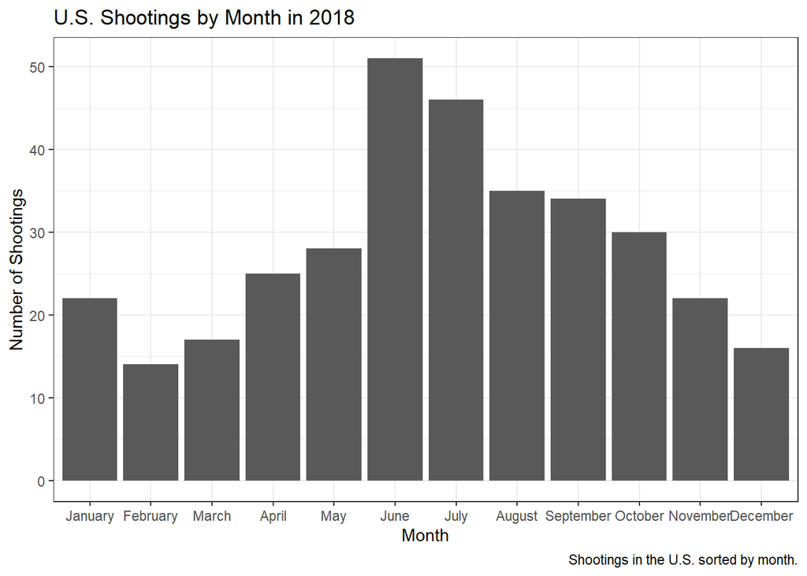